# Ford GoBike's Top Ten Start Stations

## by Aderinsola Kola-Adepoyigi

## Investigation Overview

> For the Presentation I focused on the Top 10 start stations. I explore the difference in distributions of numeric features for each start station in the top 10. I also look out for the counts per value for categorical features.

## Dataset Overview

> The dataset consisted of 183,412 records of Ford GoBike rides, after cleaning and extracting the top 10 start stations for this presentation I have 26,894 records showing thier time period, time taken, station names , ids, and other properties.

## Number of Rides for each Top 10 Start Station

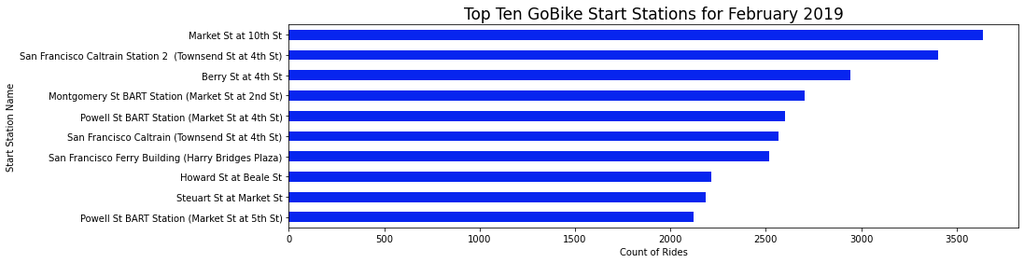

## Start Station Rides per Day of the Week

> From the plot I can observe that *San Francisco Caltrain (Townsend St at 4th St)* and *Steuart ST at Market St* both have their highest counts on Tuesday oposing the general Thursday trend observed in the remaining train stations. Also, I see that **Market St at 10th St** and *Powell St BART Station (Market St at 4th St)* have significantly higher Saturday and Sunday counts, when compared to other stations.

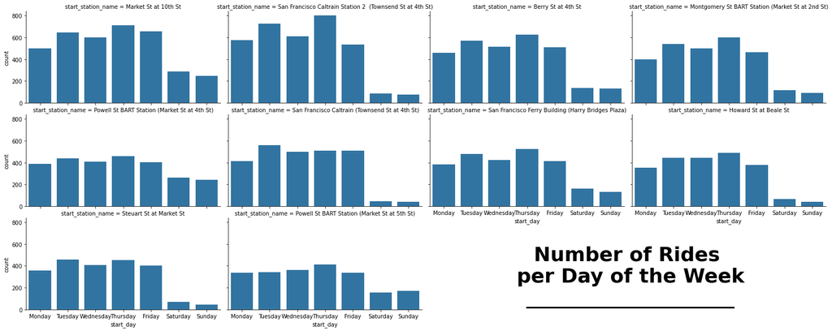

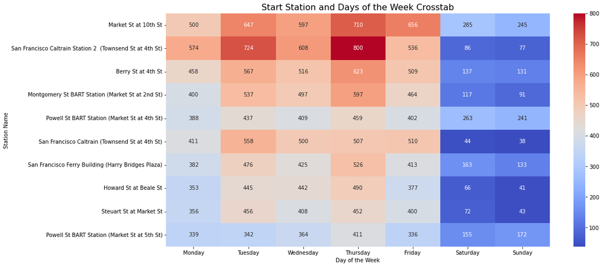

## Start Station Rides per hour of the Day

> From the plot I can observe that *San Francisco Caltrain Station 2 (Townsend St at 4th St)* has its highest count between 7-9 am when many people usually leave for work. A thought that comes to mind is that the area might be mainly residential or the most residential of the top 10, having many people leave from there to other stations for work.  
> On the other hand the stations with high traffic at the close of work hours: 16-18 pm might be filled with business/work areas. Some examples include, *Montgomery St BART Station (Market St at 2nd St)*, *Berry St at 4th St*, and *Market St at 10th St*.

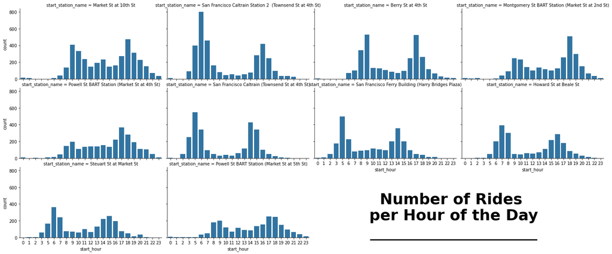

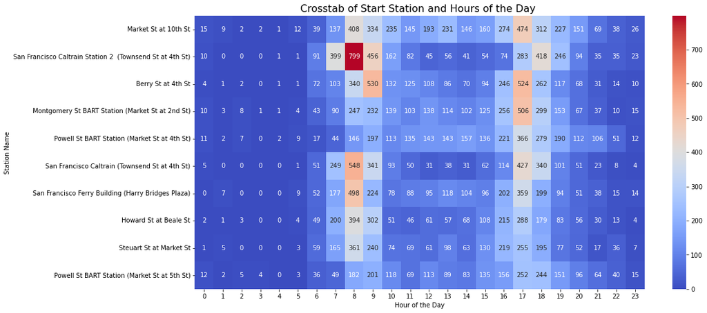

## Distribution of Displacement per Start Station

> The modal displacement value of most trips from each top 10 start station mostly falls somewhere between 1-2 km. The only exception being**Steuart St at Market St** as it has its mode between 2-2.25 km. I can also observe how dissimilar the distribution of the displacements are for values less than 3km.

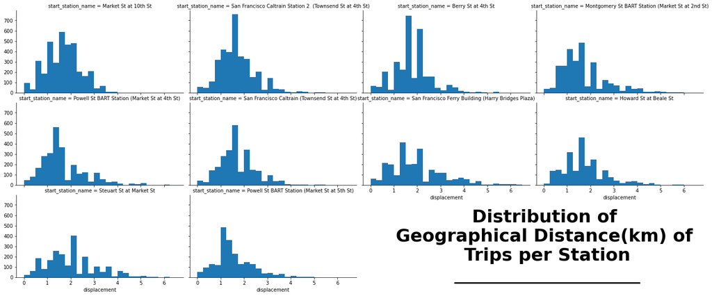

## Average Duration per Day of the Week per Start Station

> In these top 10 plots I see a trend that Saturday and Sunday generally have longer duration for trips, however, Sunday in *Montgomery St BART Station(Market St at 2nd St)* has a different behaviour. In the duration plot I see that it has the shortest average duration of about 9 minutes among all the plots. Also in the distance plot it has the smallest average displacement too.

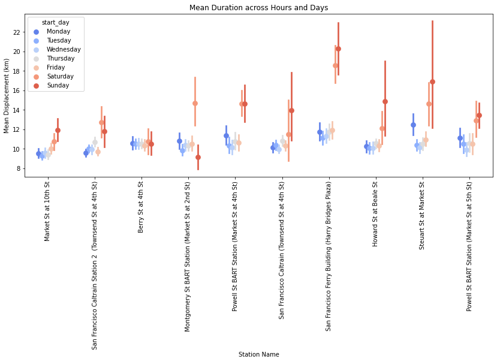

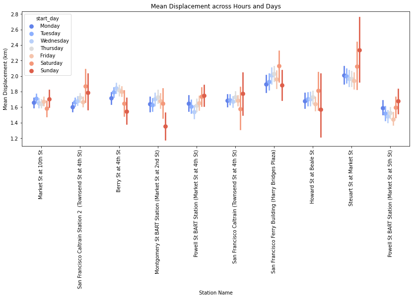